# Fluctuation and Dispersion analyses

#### Answers

Create a number of surrogates, calulate the slopes and plot the results.

- First let’s get the values we found earlier (we’ll use the FD from `sda`, then we do the same for `psd`,but you can take any of the measures as well)

```r
library(fractal)

# RR assignment data `TS1,TS2,TS3`
# Now we'll trim the time series length to a power of 2 to get the cleanest results, this is not strictly necessary
L1 <- floor(log2(length(series$TS_1)))
L2 <- floor(log2(length(series$TS_2)))
L3 <- floor(log2(length(series$TS_3)))

TS1_FDsda <- fd_sda(series$TS_1[1:2^L1])$fitRange$FD
```

```
##
##
## fd_sda:  Sample rate was set to 1.
##
##
## ~~~o~~o~~casnet~~o~~o~~~
##
##  Standardised Dispersion Analysis
##
##  Full range (n = 10)
## Slope = -0.64 | FD = 1.64
##
##  Fit range (n = 9)
## Slope = -0.61 | FD = 1.61
##
## ~~~o~~o~~casnet~~o~~o~~~
```

```r
TS2_FDsda <- fd_sda(series$TS_2[1:2^L2])$fitRange$FD
```

```
##
##
## fd_sda:  Sample rate was set to 1.
##
##
## ~~~o~~o~~casnet~~o~~o~~~
##
##  Standardised Dispersion Analysis
##
##  Full range (n = 10)
## Slope = -0.58 | FD = 1.58
##
##  Fit range (n = 9)
## Slope = -0.55 | FD = 1.55
##
## ~~~o~~o~~casnet~~o~~o~~~
```

```r
TS3_FDsda <- fd_sda(series$TS_3[1:2^L3])$fitRange$FD
```

```
##
##
## fd_sda:  Sample rate was set to 1.
##
##
## ~~~o~~o~~casnet~~o~~o~~~
##
##  Standardised Dispersion Analysis
##
##  Full range (n = 10)
## Slope = -0.64 | FD = 1.64
##
##  Fit range (n = 9)
## Slope = -0.58 | FD = 1.58
##
## ~~~o~~o~~casnet~~o~~o~~~
```

```r
# y1<-growth_ac(r = 2.9,type="logistic",N = 2^L1)
# TSlogMapr29 <- fd_sda(y1)$fitRange$FD
#
# y2<-growth_ac(r = 4,type="logistic", N = 2^L1)
# TSlogMapr4 <- fd_sda(y2)$fitRange$FD
#
# # These were rendomised
# TS1R_FDsda <- fd_sda(TS1Random[1:2^L1])$fitRange$FD
# TS2R_FDsda <- fd_sda(TS1Random[1:2^L2])$fitRange$FD
# TS3R_FDsda <- fd_sda(TS1Random[1:2^L3])$fitRange$FD
```

- To create the surrogates using `fractal::surrogate()`
  - You’ll need to repeatedly call the function and store the result
  - To get into a dataframe we have to use `unclass()` otherwise `R` doesn’t recognise the object
  - Function `t()` trnasposes the data from 39 rows to 39 columns
- Once you have the surrogates in a datafram, repeatedly calculate the measure you want to compare, in this case `fd_sda()`.

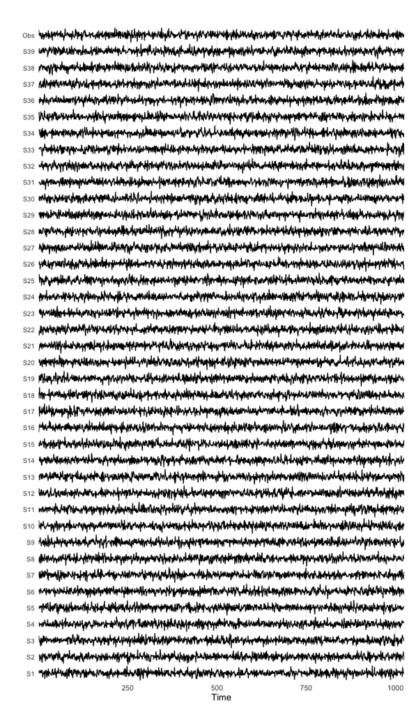

```r
# NOW CREATE SURROGATES
library(plyr)
library(tidyverse)
library(fractal)

# For a two-sided test at alpha = .05 we need N=39
Nsurrogates <- 39

TS1surrogates <- as.data.frame(t(ldply(1:Nsurrogates, function(s) unclass(surrogate(x=series$TS_1[1:2^L1] ,method="aaft")))))
colnames(TS1surrogates) <- paste0("S",1:NCOL(TS1surrogates))

# Add the observed data
TS1surrogates$Obs <- series$TS_1[1:2^L1]
plotTS_multi(TS1surrogates)
```

```r
library(fractal)
# Now we calculate FD for each series
TS1surrogates_FD <- plyr::laply(1:Nsurrogates,function(s) fd_sda(y=TS1surrogates[,s], silent = TRUE)$fitRange$FD)

TS2surrogates <- t(plyr::ldply(1:Nsurrogates, function(s) unclass(surrogate(x=series$TS_2[1:2^L2] ,method="aaft"))))
colnames(TS2surrogates) <- paste0("aaftSurr",1:NCOL(TS2surrogates))

TS2surrogates_FD <- plyr::laply(1:Nsurrogates,function(s) fd_sda(y=TS2surrogates[,s], silent = TRUE)$fitRange$FD)


TS3surrogates <- t(plyr::ldply(1:Nsurrogates, function(s) unclass(surrogate(x=series$TS_3[1:2^L3] ,method="aaft"))))
colnames(TS3surrogates) <- paste0("aaftSurr",1:NCOL(TS3surrogates))

TS3surrogates_FD <- plyr::laply(1:Nsurrogates,function(s) fd_sda(y=TS3surrogates[,s], silent = TRUE)$fitRange$FD)

#
# TSr29surrogates <- t(ldply(1:Nsurrogates, function(s) unclass(surrogate(x=y1, method="aaft"))))
# colnames(TSr29surrogates) <- paste0("aaftSurr",1:NCOL(TSr29surrogates))
#
# TSr29surrogates_FD <- laply(1:Nsurrogates,function(s) fd_sda(y=TSr29surrogates[,s], silent = TRUE)$fitRange$FD)
#
#
# TSr4surrogates <- t(ldply(1:Nsurrogates, function(s) unclass(surrogate(x=y2, method="aaft"))))
# colnames(TSr4surrogates) <- paste0("aaftSurr",1:NCOL(TSr4surrogates))
#
# TSr4surrogates_FD <- laply(1:Nsurrogates,function(s) fd_sda(y=TSr4surrogates[,s], silent = TRUE)$fitRange$FD)
```

- Collect the results in a dataframe, so we can compare.

```r
x <- data.frame(Source = c("TS1", "TS2", "TS3"), # "TSlogMapr29", "TSlogMapr4"),
                FDsda = c(TS1_FDsda, TS2_FDsda, TS3_FDsda), # TSlogMapr29, TSlogMapr4),
                #FDsdaRandom =  c(TS1R_FDsda, TS2R_FDsda, TS3R_FDsda,NA,NA),
                FDsdaAAFT.median= c(median(TS1surrogates_FD),median(TS2surrogates_FD),median(TS3surrogates_FD))) #,median(TSr29surrogates_FD),median(TSr4surrogates_FD)))
```

- Call function `plotSUR_hist()` to see the results of the test.

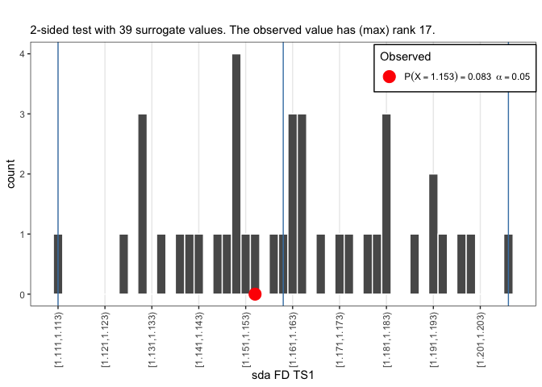

```r
plotSUR_hist(surrogateValues = TS1surrogates_FD, observedValue = TS1_FDsda, sides = "two.sided", doPlot = TRUE, measureName = "sda FD TS1")
```

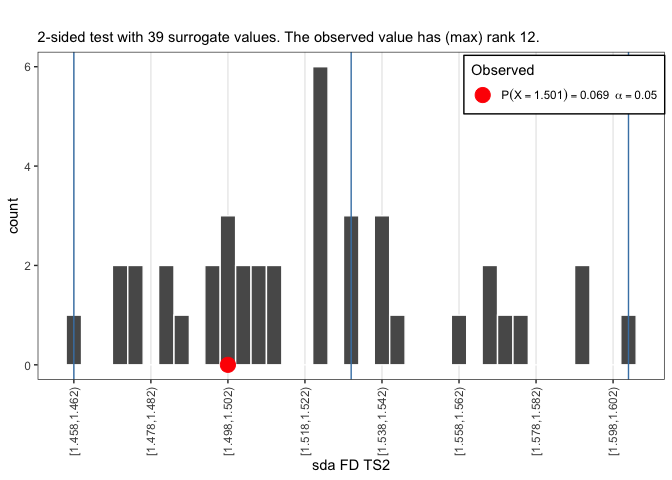

```r
plotSUR_hist(surrogateValues = TS2surrogates_FD, observedValue = TS2_FDsda, sides = "two.sided", doPlot = TRUE, measureName = "sda FD TS2")
```

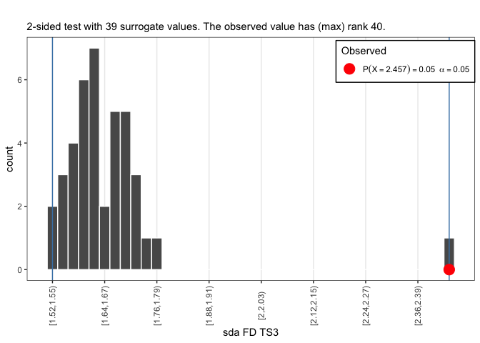

```r
plotSUR_hist(surrogateValues = TS3surrogates_FD, observedValue = TS3_FDsda,sides = "two.sided", doPlot = TRUE, measureName = "sda FD TS3")
```

```r
#
# plotSUR_hist(surrogateValues = TSr29surrogates_FD, observedValue = TSlogMapr29,sides = "two.sided", doPlot = TRUE, measureName = "sda FD logMap r=2.9")
#
# plotSUR_hist(surrogateValues = TSr4surrogates_FD, observedValue = TSlogMapr4, sides = "two.sided", doPlot = TRUE, measureName = "sda FD logMap r=4")
```

**FD: SPECTRAL SLOPE**

```r
# RR assignment data `TS1,TS2,TS3`
L1 <- floor(log2(length(series$TS_1)))
L2 <- floor(log2(length(series$TS_2)))
L3 <- floor(log2(length(series$TS_2)))

TS1_FDpsd <- fd_psd(series$TS_1[1:2^L1])$fitRange$FD
```

```
##
##
## fd_psd:  Sample rate was set to 1.
##
##
## ~~~o~~o~~casnet~~o~~o~~~
##
##  Power Spectral Density Slope
##
##  All frequencies (n = 512)
## Slope = 0.18 | FD = 1.57
##
##  Hurvich-Deo (n = 36)
## Slope = 0.29 | FD = 1.61
##
## ~~~o~~o~~casnet~~o~~o~~~
```

```r
TS2_FDpsd <- fd_psd(series$TS_2[1:2^L2])$fitRange$FD
```

```
##
##
## fd_psd:  Sample rate was set to 1.
##
##
## ~~~o~~o~~casnet~~o~~o~~~
##
##  Power Spectral Density Slope
##
##  All frequencies (n = 512)
## Slope = -0.27 | FD = 1.4
##
##  Hurvich-Deo (n = 79)
## Slope = -0.98 | FD = 1.2
##
## ~~~o~~o~~casnet~~o~~o~~~
```

```r
TS3_FDpsd <- fd_psd(series$TS_3[1:2^L3])$fitRange$FD
```

```
##
##
## fd_psd:  Sample rate was set to 1.
##
##
## ~~~o~~o~~casnet~~o~~o~~~
##
##  Power Spectral Density Slope
##
##  All frequencies (n = 512)
## Slope = 0.12 | FD = 1.54
##
##  Hurvich-Deo (n = 32)
## Slope = 0.02 | FD = 1.51
##
## ~~~o~~o~~casnet~~o~~o~~~
```

```r
# # Logistic map - make it the length of L1
# y1<-growth_ac(r = 2.9,type="logistic",N = 2^L1)
# # Turn standardisation and detrending off!
# TSlogMapr29 <- fd_psd(y1, standardise = FALSE, detrend = FALSE)$fitRange$FD
# y2<-growth_ac(r = 4,type="logistic", N = 2^L1)
# TSlogMapr4 <- fd_psd(y2, standardise = FALSE, detrend = FALSE)$fitRange$FD
#
# TS1R_FDpsd <- fd_psd(TS1Random[1:2^L1])$fitRange$FD
# TS2R_FDpsd <- fd_psd(TS1Random[1:2^L2])$fitRange$FD
# TS3R_FDpsd <- fd_psd(TS1Random[1:2^L3])$fitRange$FD
```

```r
# NOW CREATE SURROGATES
library(dplyr)

# For a two-sided test at alpha = .05 we need N=39
Nsurrogates <- 39

TS1surrogates <- t(ldply(1:Nsurrogates, function(s) unclass(fractal::surrogate(x=series$TS_1[1:2^L1] ,method="aaft"))))
colnames(TS1surrogates) <- paste0("aaftSurr",1:NCOL(TS1surrogates))

TS1surrogates_FD <- laply(1:Nsurrogates,function(s){fd_psd(y=TS1surrogates[,s], silent = TRUE)$fitRange$FD})


TS2surrogates <- t(ldply(1:Nsurrogates, function(s) unclass(surrogate(x=series$TS_2[1:2^L2] ,method="aaft"))))
colnames(TS2surrogates) <- paste0("aaftSurr",1:NCOL(TS2surrogates))

TS2surrogates_FD <- laply(1:Nsurrogates,function(s) fd_psd(y=TS2surrogates[,s], silent = TRUE)$fitRange$FD)


TS3surrogates <- t(ldply(1:Nsurrogates, function(s) unclass(surrogate(x=series$TS_3[1:2^L3] ,method="aaft"))))
colnames(TS3surrogates) <- paste0("aaftSurr",1:NCOL(TS3surrogates))

TS3surrogates_FD <- laply(1:Nsurrogates,function(s) fd_psd(y=TS3surrogates[,s], silent = TRUE)$fitRange$FD)


# TSr29surrogates <- t(ldply(1:Nsurrogates, function(s) unclass(surrogate(x=y1, method="aaft"))))
# colnames(TSr29surrogates) <- paste0("aaftSurr",1:NCOL(TSr29surrogates))
#
# TSr29surrogates_FD <- laply(1:Nsurrogates,function(s) fd_psd(y=TSr29surrogates[,s], silent = TRUE)$fitRange$FD)
#
#
# TSr4surrogates <- t(ldply(1:Nsurrogates, function(s) unclass(surrogate(x=y2, method="aaft"))))
# colnames(TSr4surrogates) <- paste0("aaftSurr",1:NCOL(TSr4surrogates))
#
# TSr4surrogates_FD <- laply(1:Nsurrogates,function(s) fd_psd(y=TSr4surrogates[,s], silent = TRUE)$fitRange$FD)
```

- Call function `plotSUR_hist()` to get the results of the test.

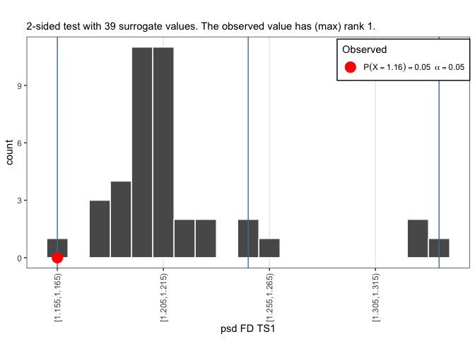

```r
plotSUR_hist(surrogateValues = TS1surrogates_FD, observedValue = TS1_FDpsd, sides = "two.sided", doPlot = TRUE, measureName = "psd FD TS1")
```

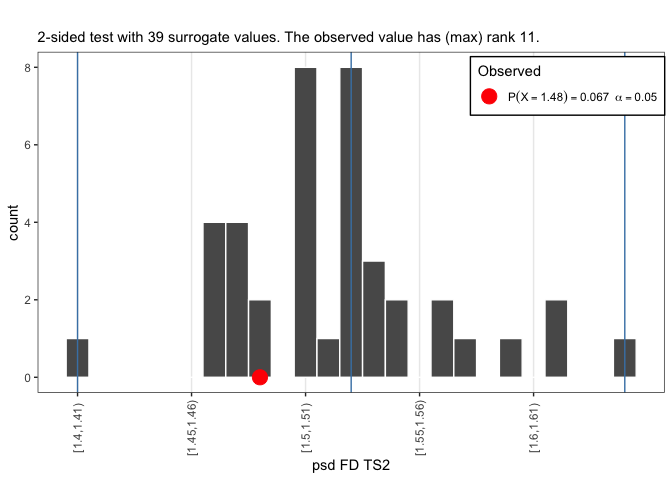

```r
plotSUR_hist(surrogateValues = TS2surrogates_FD, observedValue = TS2_FDpsd,sides = "two.sided", doPlot = TRUE, measureName = "psd FD TS2")
```

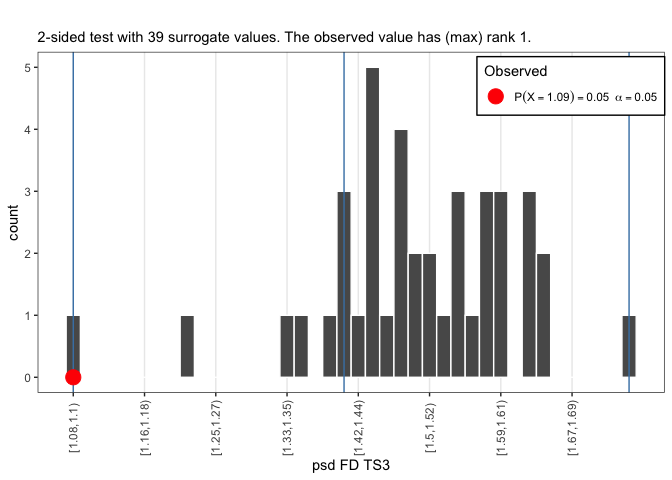

```r
plotSUR_hist(surrogateValues = TS3surrogates_FD, observedValue = TS3_FDpsd,sides = "two.sided", doPlot = TRUE, measureName = "psd FD TS3")
```

```r
# plotSUR_hist(surrogateValues = TSr29surrogates_FD, observedValue = TSlogMapr29,sides = "two.sided", doPlot = TRUE, measureName = "psd FD logMap r=2.9")
#
# plotSUR_hist(surrogateValues = TSr4surrogates_FD, observedValue = TSlogMapr4, sides = "two.sided", doPlot = TRUE, measureName = "psd FD logMap r=4")
```

- Let’s print the results into a table

```r
x$FDpsd <- c(TS1_FDpsd,TS2_FDpsd,TS3_FDpsd) #TSlogMapr29,TSlogMapr4)
#x$FDpsdRandom <- c(TS1R_FDpsd, TS2R_FDpsd, TS3R_FDpsd,NA,NA)
x$FDpsdAAFT.median <- c(median(TS1surrogates_FD),median(TS2surrogates_FD),median(TS3surrogates_FD)) #,median(TSr29surrogates_FD),median(TSr4surrogates_FD))
knitr::kable(x, digits = 2, booktabs=TRUE,formt="html")
```

| Source | FDsda | FDsdaAAFT.median | FDpsd | FDpsdAAFT.median |
| --- | --- | --- | --- | --- |
| TS1 | 1.15 | 1.16 | 1.16 | 1.21 |
| TS2 | 1.50 | 1.52 | 1.48 | 1.52 |
| TS3 | 2.46 | 1.64 | 1.09 | 1.50 |